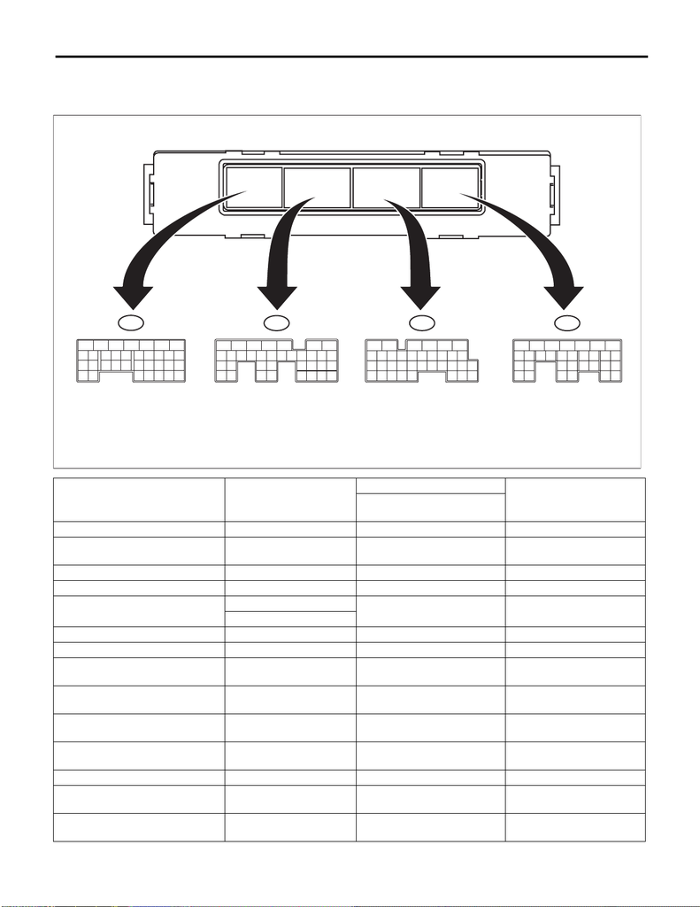

BC(diag)-6

Control Module I/O Signal

BODY CONTROL SYSTEM (DIAGNOSTICS)

5. Control Module I/O Signal

A: ELECTRICAL SPECIFICATION

Description Terminal No.

Signal (V or Ω)

Note

Ignition switch ON

(engine OFF)

Ignition power supply (rear wiper) A5 ←→ Chassis ground Less than 1.5 V → 10 — 13 V Ignition switch OFF → ON

Battery power supply (shift lock/key

lock)

B6 ←→ Chassis ground 10 — 13 V Always

Battery power supply (door lock) D1 ←→ Chassis ground 10 — 13 V Always

Battery power supply (control) C6 ←→ Chassis ground 10 — 13 V Always

Ground

A1 ←→ Chassis ground

Less than 1.5 V Always

C1 ←→ Chassis ground

Battery power supply (back-up) B7 ←→ Chassis ground 10 — 13 V Always

Ignition power supply B3 ←→ Chassis ground Less than 1.5 V → 10 — 13 V Ignition switch OFF → ON

ACC power supply A32 ←→ Chassis ground Less than 1.5 V → 10 — 13 V

Ignition switch OFF →

Accessory ON

Key-in switch A4 ←→ Chassis ground Less than 1.5 V → 10 — 13 V

Key inserted (models without

keyless access)

ACC input A4 ←→ Chassis ground Less than 1.5 V → 10 — 13 V

ACC ON (model with keyless

access)

P range SW B18 ←→ Chassis ground 8 V or more → less than 1.5 V

P range to other than P

range

Stop light SW A10 ←→ Chassis ground Less than 1.5 V → 8 V Stop light switch OFF → ON

Door SW (driver’s) C14 ←→ Chassis ground 8 V or more → less than 1.5 V

Front right door closed →

open

Door SW (passenger’s) C13 ←→ Chassis ground 8 V or more → less than 1.5 V

Front left door closed →

open

[figure not shown]

BC(diag)-7

Control Module I/O Signal

BODY CONTROL SYSTEM (DIAGNOSTICS)

Door SW (rear right) C25 ←→ Chassis ground 8 V or more → less than 1.5 V

Rear right door closed →

open

Door SW (rear left) C24 ←→ Chassis ground 8 V or more → less than 1.5 V

Rear left door closed →

open

Rear gate SW/trunk SW C33 ←→ Chassis ground 8 V or more → less than 1.5 V

Rear gate/trunk closed →

open

Opener SW (trunk/rear gate) C10 ←→ Chassis ground 8 V or more → less than 1.5 V

Rear gate/trunk opener

switch ON

Manual switch (LOCK) C9 ←→ Chassis ground 8 V or more → less than 1.5 V Door lock switch ON

Manual switch (UNLOCK) C20 ←→ Chassis ground 8 V or more → less than 1.5 V Door unlock switch ON

Lighting AUTO B16 ←→ Chassis ground 8 V or more → less than 1.5 V Switch at AUTO position

Lighting II

A34 ←→ Chassis ground

8 V or more → less than 1.5 V Switch at II position

B34 ←→ Chassis ground

Lighting I B17 ←→ Chassis ground 8 V or more → less than 1.5 V Switch at I position

Dimmer passing B25 ←→ Chassis ground 8 V or more → less than 1.5 V Switch at passing position

Dimmer Hi beam B15 ←→ Chassis ground 8 V or more → less than 1.5 V Switch at Hi beam position

Front fog light SW B26 ←→ Chassis ground 8 V or more → less than 1.5 V Front fog light switch ON

Illumination sensor power supply B1 ←→ A29

Less than 1.5 V → 4.5 V or

more

Ignition switch OFF → ON

Illumination sensor signal A19 0.2 — 4.5 V Ignition switch OFF → ON

Ground (illumination sensor) A29 ←→ Chassis ground Less than 1.5 V Always

Rear wiper SW ON A12 ←→ Chassis ground 8 V or more → less than 1.5 V Switch at ON position

Rear wiper SW INT A22

←→ Chassis ground 8 V or more → less than 1.5 V Switch at INT position

Rear washer SW A30 ←→ Chassis ground 8 V or more → less than 1.5 V Switch at ON position

Illumination SW (Vi1) D12 ←→ Chassis ground Approx. 5 V

While clearance light illumi-

nates

Illumination SW (Vi2) D22 ←→ Chassis ground 0.5 — 4.8 V

Illumination SW (Vi3) D28 ←→ Chassis ground Less than 1.5 V Always

Bright SW C21 ←→ Chassis ground 8 V or more → less than 1.5 V Switch at ON position

Reverse SW (MT) B12 ←→ Chassis ground Less than 1.5 V → 8 V or more Reverse SW ON

Impact sensor A11 ←→ Chassis ground 8 V or more Apply an impact

Hi-speed CAN communication cir-

cuit 1 (Hi)

B20

Serial communication Except for sleep status*1

Hi-speed CAN communication cir-

cuit 1 (Lo)

B28

Hi-speed CAN communication cir-

cuit 2 (Hi)

C27

Serial communication Except for sleep status*1

Hi-speed CAN communication cir-

cuit 2 (Lo)

C35

Immobilizer antenna (B) B22

Serial communication

Communication with ignition

key in progress

Immobilizer antenna (A) B10

Immobilizer antenna amplifier GND B30 ←→ Chassis ground Less than 1.5 V Always

Immobilizer antenna amplifier

power supply

B2 ←→ B30 4.5 — 5.5 V

Communication with ignition

key in progress

Security UART A21 Serial communication Always

Front wiper return A2 ←→ Chassis ground 8 V When front wiper is operated

Rear washer switch A30 ←→ Chassis ground 8 V or more → less than 1.5 V

When rear washer switch is

ON

Door UNLOCK (driver’s seat) out-

put

D4 ←→ Chassis ground Less than 0.5 V → 8 V or more

When driver’s side door

unlock is output

Description Terminal No.

Signal (V or Ω)

Note

Ignition switch ON

(engine OFF)

[figure not shown]

BC(diag)-8

Control Module I/O Signal

BODY CONTROL SYSTEM (DIAGNOSTICS)

*1: For CAN sleep state, hold on for approx. one minute with ignition OFF and the doors, trunk, and rear gate all closed.

Keyless entry communication line D11 Serial communication

When door lock/unlock is

operated with the keyless

transmitter, or when TPMS is

operated

Rear defogger switch C18 ←→ Chassis ground Less than 1.5 V → 8 V or more

When the rear defogger

switch is ON

Parking brake switch C32 ←→ Chassis ground 8 V or more → less than 1.5 V When parking brake is ON

Shift lock solenoid B5 ←→ Chassis ground Less than 1.5 V → 8 V or more

When shift lock is operating

(AT models)

Key lock solenoid B4 ←→ Chassis ground Less than 1.5 V → 8 V or more

LOCK status is ON (AT mod-

els without keyless access)

Rear wiper ON output A7 ←→ Chassis ground Less than 0.5 V → 8 V or more

Rear wiper operation in

progress

Rear wiper return A6 ←→ Chassis ground Less than 0.5 V → 8 V or more

Rear wiper operation in

progress

Door LOCK output D2 ←→ Chassis ground Less than 0.5 V → 8 V or more When LOCK signal is output

Door UNLOCK output D3 ←→ Chassis ground Less than 0.5 V → 8 V or more

When UNLOCK signal is

output

Rear gate/trunk UNLOCK output D7 ←→ Chassis ground Less than 0.5 V → 8 V or more

When UNLOCK signal is

output

Lighting relay power supply

A3 ←→ Chassis ground 10 — 13 V ACC or key-in SW ON

B19 ←→ Chassis ground 10 — 13 V ACC or key-in SW ON

Lighting relay Hi output A17 ←→ Chassis ground 8 V or more → less than 1.0 V Dimmer SW at Hi position

Lighting relay Lo output B35 ←→ Chassis ground 8 V or more → less than 1.0 V Lighting II SW at ON position

Lighting Lo relay output 2 A27 ←→ Chassis ground 8 V or more → less than 1.0 V Lighting II SW at ON position

Lighting relay I output A16 ←→ Chassis ground 8 V or more → less than 1.0 V Lighting I SW at ON position

Front fog light output A15 ←→ Chassis ground 8 V or more → less than 1.0 V

Front fog light SW at ON

position

DRL cancel output D10

←→ Chassis ground 8 V or more → less than 1.0 V

Headlight switch ON or Hi

beam ON, passing switch

ON

Illumination output

B8 Pulse output Illumination ON

C16 Pulse output Illumination ON

Key ring illumination A25 Pulse output Illumination ON

Room light output C4 Pulse output

Room light ON (doors inter-

locked)

Map light output D8 Pulse output

Map light ON (keyless

answer-back, etc.)

Luggage/trunk light output C3 Pulse output Luggage/trunk at open state

Rear defogger relay output A26 ←→ Chassis ground 8 V or more → less than 1.0 V Rear defogger SW ON

Wiper deicer relay output D9 ←→ Chassis ground 8 V or more → less than 1.0 V Wiper deicer SW ON

Turn/hazard output D18 ←→ Chassis ground 8 V or more → less than 1.0 V When answer-back is output

Security horn output A24 ←→ Chassis ground 8 V or more → less than 1.0 V When security is operating

Security light D26 Pulse control

When security light is illumi-

nating

Answer-back buzzer output A20 ←→ Chassis ground 8 V or more → less than 1.0 V When answer-back operates

Immobilizer communication A31 Serial communication

(Model without keyless

access)

Description Terminal No.

Signal (V or Ω)

Note

Ignition switch ON

(engine OFF)